# M1 CV - TP3 : Un arc-en-ciel de couleurs :D

Aujourd'hui, on oublie les images en niveaux de gris, et on passe aux images couleurs. Pourquoi passer à la couleur ? Pourquoi abandonner les images en niveaux de gris ? Que nous cache Lena en couleur ? Vous le saurez aujourd'hui dans ce TP....

```python
# Chargement des librairies
import cv2
from matplotlib import pyplot as plt
import numpy as np
```

```python
from skimage.io import imread
import matplotlib.pyplot as plt
```

```python
!pip install opencv-python
```

```python
path_base = ...
```

```python
files = []
files.append("crayons.jpg")
files.append("HSVCone.png")
files.append("HSVWheel.png")
files.append("iron_man.jpg")
```

```python
files[0]
```

```
'crayons.jpg'
```

```python
def lever_exception(f):
    '''
    Notre fameuse fonction qui lève des exceptions
    '''
    raise Exception("Il y'a un problème au niveau de la fonction ",f)
```

```python
def get_image(file):
    '''
    Cette fontion permet d'ouvrir des images en couleur
    '''
    #img = cv2.imread(file)#, cv2.IMREAD_GRAYSCALE)
    img = plt.imread(file)
    return img
```

```python
def print_image(img):
    '''
    Cette fonction sert à afficher des images en couleurs
    '''
    plt.imshow(img)
```

```python
img1 = get_image(files[0])
img2 = get_image(files[1])
img3 = get_image(files[2])
img4 = get_image(files[3])
```

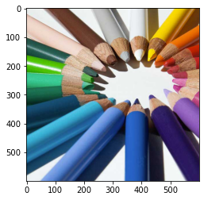

```python
print_image(img1)
```

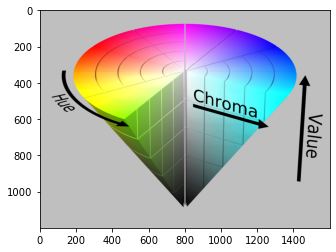

```python
print_image(img2)
```

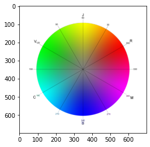

```python
print_image(img3)
```

[figure not shown]

```python
print_image(img4)
```

## Ex. 0 : Comment ça ? Il y a d'autres espaces de couleurs autres que RGB ?

Et oui ! On connaît le fameux espace de couleur RGB, mais il en existe plein d'autres. Pour ce TP, on va en découvrir quelques uns. Mais d'abord, choississons une image couleur à étudier (crayons.jpg aujourd'hui). Chargez là, et affichez la (attention, je veux obligatoirement du RGB !!)

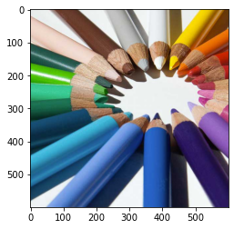

```python
# A compléter
# Chargement et affichage de crayons.jpg EN COULEUR !
print_image(img1)
```

```python
img1
```

```
array([[[233, 237, 236],
        [233, 237, 236],
        [233, 237, 236],
        ...,
        [102,  58,   9],
        [102,  58,   9],
        [102,  58,   9]],

       [[233, 237, 236],
        [233, 237, 236],
        [233, 237, 236],
        ...,
        [102,  58,   9],
        [102,  58,   9],
        [102,  58,   9]],

       [[233, 237, 236],
        [233, 237, 236],
        [233, 237, 236],
        ...,
        [102,  58,   9],
        [102,  58,   9],
        [102,  58,   9]],

       ...,

       [[239, 243, 246],
        [239, 243, 246],
        [239, 243, 246],
        ...,
        [ 41,  26,  95],
        [ 41,  26,  95],
        [ 41,  26,  95]],

       [[239, 243, 246],
        [239, 243, 246],
        [239, 243, 246],
        ...,
        [ 41,  26,  95],
        [ 41,  26,  95],
        [ 41,  26,  95]],

       [[239, 243, 246],
        [239, 243, 246],
        [239, 243, 246],
        ...,
        [ 41,  26,  95],
        [ 41,  26,  95],
        [ 41,  26,  95]]], dtype=uint8)
```

Durant ce TP, nous allons découvrir plusieurs espaces de couleurs, leur utilité et leurs particularités. Vous vous en doutez, OpenCV fait tout, et notamment les conversions dans différents espaces de couleur. Maintenant, comme c'est un TP, je vais vous demander donc de développer les conversions vous-même, mais on fera une comparaison avec les conversions via OpenCV.

## Ex. 1 : CMYK, on commence tranquille

Commençons avec l'espace de couleur CMYK (pour Cyan, Magenta, Yellow et blacK). Celui-ci, vous le connaissez, c'est utilisé pour les impressions. Le principe, c'est que contrairement, ou la synthèse est additive (toutes les composantes R, G et B en quantité maximale donne la couleur blanche); ici, la synthèse est soustractive (toutes les composantes C, M et Y en quantité maximale donne la couleur noire). La dernière composante, noire, permet tout simplement de minimiser les composantes couleurs, plus chères que la composante noire lors de l'impression.

La conversion n'est pas disponible via OpenCV, mais elle reste assez simple pour autant, avec r, g et b les composantes Red, Green et Blue normalisées (float entre 0 et 1) :

\begin{equation*} k = 1-max(r,g,b) \\ c = 1-r-k \\ m = 1-g-k \\ y = 1-b-k \\ \end{equation*}

```python
img1.shape
```

```
(600, 600, 3)
```

```python
def get_img_size(img):
    return img.shape
```

```python
def get_max_pix(img):
    size = get_img_size(img)
    r = []
    g = []
    b = []
    for i in range(size[0]):
        for j in range(size[1]):
            ri, gi, bi = img[i,j]
            r.append(ri)
            g.append(gi)
            b.append(bi)
    return np.array([np.max(r),np.max(g),np.max(b)])
```

```python
def get_min_pix(img):
    size = get_img_size(img)
    r = []
    g = []
    b = []
    for i in range(size[0]):
        for j in range(size[1]):
            ri, gi, bi = img[i,j]
            r.append(ri)
            g.append(gi)
            b.append(bi)
    return np.array([np.min(r),np.min(g),np.min(b)])
```

```python
def img_normalisation(img):
    size = img.shape
    img_norm = np.zeros((img.shape))#.astype(np.uint8)
    pmin = get_min_pix(img)
    pmax = get_max_pix(img)
    den = pmax - pmin
    print((img[0,0]-pmin)/den)
    for i in range(size[0]):
        for j in range(size[1]):
            img_norm[i,j] = (img[i,j] - pmin)/den
    return img_norm
```

```python
i = img_normalisation(img1)
```

```
[0.91372549 0.92941176 0.9254902 ]
```

```python
# A compléter
# Fonction de conversion de l'image RGB en CMYK
def from_rgb_to_cmyk(img):
    img_norm = img_normalisation(img)
    size = img.shape
    new_img = np.zeros((size[0],size[1],4))
    new_img_c = np.zeros((size[0], size[1],4))
    new_img_m = np.zeros((size[0], size[1],4))
    new_img_y = np.zeros((size[0], size[1],4))
    new_img_k = np.zeros((size[0], size[1],4))
    old_img = np.zeros(size)
    for i in range(size[0]):
        for j in range(size[1]):
            bgr = img[i,j].astype(float)/255
            k = 1 - np.max(bgr, axis=0)
            r, g, b = img_norm[i,j]
            c = 1 - r - k
            m = 1 - g - k
            y = 1 - b - k
            new_img[i,j] = (c,m,y,k)
            new_img_c[i,j] = (c,0,0,0)
            new_img_m[i,j] = (0,m,0,0)
            new_img_y[i,j] = (0,0,y,0)
            new_img_k[i,j] = (0,0,0,k)
            new_r = 1 - c - k
            new_g = 1 - m - k
            new_b = 1 - y - k
            old_img[i,j] = (new_r,new_g,new_b)
    return new_img, old_img, new_img_c, new_img_m, new_img_y, new_img_k
```

```python
im, im_old, im_c, im_m, im_y, im_k = from_rgb_to_cmyk(img1)
```

```
[0.91372549 0.92941176 0.9254902 ]
```

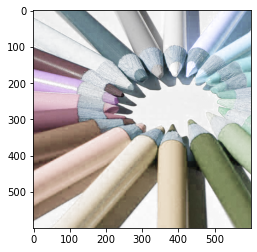

```python
print_image(im)
```

Affichez le résultat channel par channel. Attention, ici, on va affichez le résultat comme dans le cadre d'une impression : notre image est donc à la base blanche, et on affichera chaque channel en soustrayant celui-ci à la "feuille blanche".

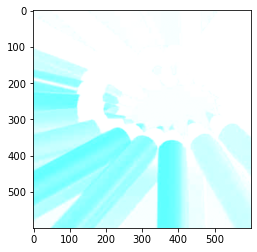

```python
# A compléter
# Affichage du résultat channel par channel sur une "feuille blanche"
print_image(1 - im_c)
```

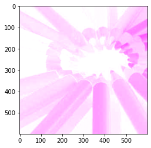

```python
print_image(1 - im_m)
```

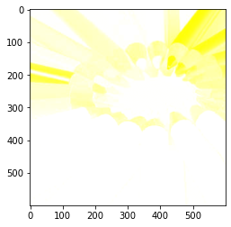

```python
print_image(1 - im_y)
```

[figure not shown]

```python
print_image(1 - im_k)
```

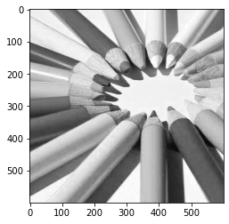

```python
print_image(im_k)
```

Et pour finir tranquillement cet exercice, recréez l'image RGB de base à partir de la "feuille blanche" et des composantes C, M, Y et K à soustraire.

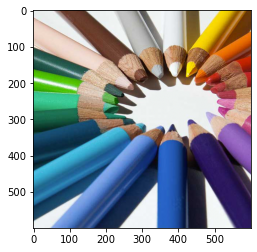

```python
# A compléter
# Affichage de la feuille imprimée (feuille blanche où on retire les composantes C,M,Y et K)
print_image(im_old)
```

## Ex. 2 : YUV (optionnel)

Continuons ce TP avec l'espace de couleur YUV. Cet espace de couleurs a été conçu en 1960 pour une raison très précise. A cette époque, les premières télévisions couleurs apparaissent, et les chaînes de télévision doivent donc envoyer un signal pour 2 types de télévisions différentes : les télévisions couleurs et les télévisions Noir et Blanc. Cependant, les plus anciennes télévisions ne sont pas adaptées pour traiter un signal différent que ceux qu'elles recevaient avant : on ne peut donc envoyer un signal style RGB et faire la conversion en N&B à la réception. Pour cela, il fallait envoyer un signal comprenant l'info en niveau de gris, comme auparavant, mais avec des autres composantes pour afficher la couleur pour les télévisions qui le peuvent.

Pour cela, l'espace de couleur YUV a été créé. Il est composé d'une composante luminance (Y) contenant l'information en N&B, et 2 composantes chrominances (U et V) contenant l'information couleur. Par exemple, dans la plage suivante, les composantes U et V permettent de caractériser ces couleurs, pour Y = 0.5. Ce que cela veut dire, c'est que toutes ces couleurs converties en N&B donneront uniquement 0.5, soit Y.

[figure not shown]

Pour ce faire, on va utiliser les formules suivantes, avec r, g et b les composantes Red, Green et Blue normalisées (float entre 0 et 1) : \begin{equation*} y = r + g + b \\ u = b - y \\ v = r - y \end{equation*}

*Note :* si vous n'avez pas le même résultat qu'OpenCV, c'est normal : on utilise une version très simplifiée, sans applicateurs correctifs. La version d'OpenCV, nettement améliorée, permet d'obtenir un channel Y (niveaux de gris) beaucoup plus fidèle que pour notre version.

```python
# A compléter
# Fonction de conversion manuelle de l'image RGB en YUV
def from_rgb_to_yuv(img):
    img_norm = img_normalisation(img)
    size = img.shape
    new_img = np.zeros((size[0],size[1],3))
    new_img_y = np.zeros((size))
    new_img_u = np.zeros((size))
    new_img_v = np.zeros((size))
    old_img = np.zeros(size)
    for i in range(size[0]):
        for j in range(size[1]):
            r, g, b = img_norm[i,j]
            y = r + g + b # r = y - g - b
            u = b - y # => b = u + y
            v = r - y # => y = r - v => r + g + b = r - v => g = r - v - r - b
            new_img[i,j] = (y,u,v)
            new_img_y[i,j] = (y,0,0)
            new_img_u[i,j] = (0,u,0)
            new_img_v[i,j] = (0,0,v)
            #
            new_r = y - g - b
            new_g = v - b
            new_b = u + y
            #
            old_img[i,j] = (new_r,new_g,new_b)
    return new_img, old_img, new_img_y, new_img_u, new_img_v
```

```python
im, im_old, im_y, im_u, im_v = from_rgb_to_yuv(img1)
```

```
[0.91372549 0.92941176 0.9254902 ]
```

```python
# A compléter
# Affichage des résultats channel par channel
img_yuv = cv2.cvtColor(img1, cv2.COLOR_RGB2YUV)
y, u, v = cv2.split(img_normalisation(img_yuv))
img_res = np.vstack([y, u, v])
```

```
[0.92519685 0.64880952 0.43127962]
```

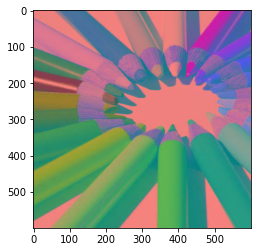

```python
print_image(img_yuv)
```

```python
y, u, v = cv2.split(img_yuv)
```

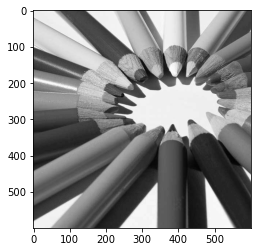

```python
plt.imshow(y,cmap="gray")
```

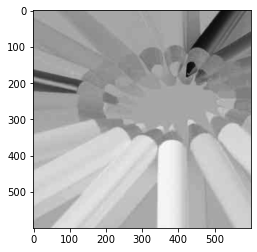

```python
plt.imshow(u,cmap="gray")
```

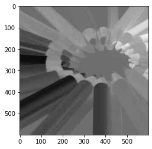

```python
plt.imshow(v,cmap="gray")
```

Affichez le résultat channel par channel des résultats obtenus.

```python
print_image(img_res)
```

[output not shown]